# 6. Project Models to Multiple Scenarios

# Summary

- Description
- Getting ready
- Fitted models
- Variables for projections
  - Variables from WorldClim
  - Format for renaming
  - Static variables
  - Organizing files
- Preparing data for projections
- Projecting to multiple scenarios
- Importing results from projections
- Detecting changes in projections
  - Setting colors for maps
  - Types of results
  - Importing results
  - Saving results

# Description

Once selected models have been fit and explored, projections to single or multiple scenarios can be performed. The `project_selected()` function is designed for projections to multiple scenarios (i.e., multiple sets of data, each representing distinct environmental scenarios). This vignette contains examples of how to use many of the options available for model projections.

# Getting ready

At this point it is assumed that `kuenm2` is installed (if not, see the [Main guide](https://marlonecobos.github.io/kuenm2/)). Load `kuenm2` and any other required packages, and define a working directory (if needed).

Note: functions from other packages (i.e., not from base R or `kuenm2`) used in this guide will be displayed as `package::function()`.

```r
# Load packages
library(kuenm2)
library(terra)

# Current directory
getwd()

# Define new directory
#setwd("YOUR/DIRECTORY")  # uncomment and modify if setting a new directory

# Saving original plotting parameters
original_par <- par(no.readonly = TRUE)
```

# Fitted models

To project selected models, a `fitted_models` object is required. For detailed information on model fitting, check the vignette Fit and Explore Selected Models. The `fitted_models` object generated in that vignette is included as an example dataset within the package. Let’s load it.

```r
# Import fitted_model_maxnet
data("fitted_model_maxnet", package = "kuenm2")

# Print fitted models
fitted_model_maxnet
```

```
#> fitted_models object summary
#> ============================
#> Species: Myrcia hatschbachii
#> Algortihm: maxnet
#> Number of fitted models: 2
#> Models fitted with 4 replicates
```

# Variables for projections

Predicting models for a single scenario requires a single `SpatRaster` object containing the variables (as detailed in Predict Models to a Single Scenario). In contrast, projecting models to multiple scenarios requires a folder that stores variables for each scenario organized in a certain way.

To ensure the following automated process can correctly track variables, the data must follow a strict hierarchical directory structure. At the top level, a *Base Directory* serves as the primary container for all project data. Inside this base folder, the first level of organization consists of subfolders for distinct *Time Periods*, such as future years (e.g., “2070”, “2100”) or paleoclimate eras (e.g., “Mid-holocene”, “LGM”). Within each period folder, *if applicable*, you should include subfolders at the second level for each *Emission Scenario* (e.g., “ssp126”, “ssp585”). Finally, within each emission scenario or time period folder, the third level should include a separate folder for each *General Circulation Model* (GCM) (e.g., “BCC-CSM2-MR”, “MIROC6”) to house the actual raster variables. This structured organization enables the function to automatically access and process the data according to period, emission scenario, and GCM.

## Variables from WorldClim

The package provides a function to import future climate variables downloaded from WorldClim (version 2.1). This function renames the files and organizes them into folders categorized by period/year, emission scenario (Shared Socioeconomic Pathways; SSPs), and General Circulation Model (GCM). This simplifies the preparation of climate data, ensuring all required variables are properly structured for modeling projections.

To use this function, download the [future raster variables from WorldClim 2.1](https://worldclim.org/data/cmip6/cmip6climate.html) and save them all within the same folder. **DO NOT rename the files or the variables**, as the function relies on the patterns provided in the original files to work properly.

```r
# See raster files with future variables provided as example
# The data is located in the "inst/extdata" folder.
in_dir <- system.file("extdata", package = "kuenm2")
list.files(in_dir)
```

```
#>  [1] "CHELSA_LGM_CCSM4.tif"
#>  [2] "CHELSA_LGM_CNRM-CM5.tif"
#>  [3] "CHELSA_LGM_FGOALS-g2.tif"
#>  [4] "CHELSA_LGM_IPSL-CM5A-LR.tif"
#>  [5] "CHELSA_LGM_MIROC-ESM.tif"
#>  [6] "CHELSA_LGM_MPI-ESM-P.tif"
#>  [7] "CHELSA_LGM_MRI-CGCM3.tif"
#>  [8] "Current_CHELSA.tif"
#>  [9] "Current_variables.tif"
#> [10] "bias_file.tif"
#> [11] "m.gpkg"
#> [12] "wc2.1_10m_bioc_ACCESS-CM2_ssp126_2041-2060.tif"
#> [13] "wc2.1_10m_bioc_ACCESS-CM2_ssp126_2081-2100.tif"
#> [14] "wc2.1_10m_bioc_ACCESS-CM2_ssp585_2041-2060.tif"
#> [15] "wc2.1_10m_bioc_ACCESS-CM2_ssp585_2081-2100.tif"
#> [16] "wc2.1_10m_bioc_MIROC6_ssp126_2041-2060.tif"
#> [17] "wc2.1_10m_bioc_MIROC6_ssp126_2081-2100.tif"
#> [18] "wc2.1_10m_bioc_MIROC6_ssp585_2041-2060.tif"
#> [19] "wc2.1_10m_bioc_MIROC6_ssp585_2081-2100.tif"
#> [20] "world.gpkg"
```

Note that all variables are in the same folder and retain the original names provided by WorldClim. You can download these variables directly from [WorldClim](https://worldclim.org/data/cmip6/cmip6climate.html) or by using the `geodata` R package (see example code below):

```r
# Install geodata if necessary
if (!require("geodata")) {
  install.packages("geodata")
}

# Load geodata
library(geodata)

# Create folder to save the raster files
# Here, in a temporary directory
geodata_dir <- file.path(tempdir(), "Future_worldclim")
dir.create(geodata_dir)

# Define GCMs, SSPs and time periods
gcms <- c("ACCESS-CM2", "MIROC6")
ssps <- c("126", "585")
periods <- c("2041-2060", "2061-2080")

# Create a grid of combination of periods, ssps and gcms
g <- expand.grid("period" = periods, "ssps" = ssps, "gcms" = gcms)
g  # Each line is a specific scenario for future

# Loop to download variables for each scenario (It can take a while)
lapply(1:nrow(g), function(i) {
  cmip6_world(model = g$gcms[i],
              ssp = g$ssps[i],
              time = g$period[i],
              var = "bioc",
              res = 10, path = geodata_dir)
})
```

Let’s check the variables inside the “geodata_dir” folder:

```r
list.files(geodata_dir, recursive = TRUE)
```

[output not shown]

Now, we can organize and structure the files using the `organize_future_worldclim()` function.

## Format for renaming

The argument `name_format` defines the format for renaming variables. The names of the variables in the `SpatRaster` must precisely match those used when preparing data, even if a PCA was performed internally (if `do_pca = TRUE`; see Prepare Data for Model Calibration for details). If the variables used to create the models were “bio_1”, “bio_2”, etc., the variables representing other scenarios must be “bio_1”, “bio_2”, etc. However, if the names don’t match exactly, projections can fail (always check uppercase letters or zeros before single-digit numbers (e.g., “Bio_01”, “Bio_02”, etc.). The function `organize_future_worldclim()` provides four renaming options:

1. `"bio_"`: Variables will be renamed to `bio_1`, `bio_2`, `bio_3`, `bio_10`, etc.
2. `"bio_0"`: Variables will be renamed to `bio_01`, `bio_02`, `bio_03`, `bio_10`, etc.
3. `"Bio_"`: Variables will be renamed to `Bio_1`, `Bio_2`, `Bio_3`, `Bio_10`, etc.
4. `"Bio_0"`: Variables will be renamed to `Bio_01`, `Bio_02`, `Bio_03`, `Bio_10`, etc.

Let’s check how the variables were named in our `fitted_model`:

```r
fitted_model_maxnet$continuous_variables
```

```
#> [1] "bio_1"  "bio_7"  "bio_12" "bio_15"
```

The variables follow the standards of the first option (`"bio_"`).

## Static variables

When predicting to other times, some variables could be static (i.e., they remain unchanged in scenarios of projections). The `static_variables` argument allows users to append static variables alongside the Bioclimatic ones. First, let’s bring `soilType`, which will remain static in future scenarios (we will use it in a later step).

```r
# Import raster layers (same used to calibrate and fit final models)
var <- rast(system.file("extdata", "Current_variables.tif", package = "kuenm2"))

# Get soilType
soiltype <- var$SoilType
```

## Organizing files

Now, let’s organize the WorldClim files with the `organize_future_worldclim()` function:

```r
# Create folder to save structured files
out_dir_future <- file.path(tempdir(), "Future_raw")  # a temporary directory

# Organize
organize_future_worldclim(input_dir = in_dir,  # Path to variables from WorldClim
                          output_dir = out_dir_future,
                          name_format = "bio_",  # Name format
                          static_variables = var$SoilType)  # Static variables
```

```
#>   |                                                                              |                                                                      |   0%  |                                                                              |=========                                                …
#>
#> Variables successfully organized in directory:
#> C:\Users\wever\AppData\Local\Temp\RtmpIdK2IK/Future_raw
```

```r
# Check files organized
dir(out_dir_future, recursive = TRUE)
```

```
#> [1] "2041-2060/ssp126/ACCESS-CM2/Variables.tif"
#> [2] "2041-2060/ssp126/MIROC6/Variables.tif"
#> [3] "2041-2060/ssp585/ACCESS-CM2/Variables.tif"
#> [4] "2041-2060/ssp585/MIROC6/Variables.tif"
#> [5] "2081-2100/ssp126/ACCESS-CM2/Variables.tif"
#> [6] "2081-2100/ssp126/MIROC6/Variables.tif"
#> [7] "2081-2100/ssp585/ACCESS-CM2/Variables.tif"
#> [8] "2081-2100/ssp585/MIROC6/Variables.tif"
```

We can check the files structured hierarchically in nested folders using the `dir_tree()` function from the `fs` package:

```r
# Install package if necessary
if (!require("fs")) {
  install.packages("fs")
}

dir_tree(out_dir_future)
```

```
#> Temp\RtmpkhmGWN/Future_raw
#> ├── 2041-2060
#> │   ├── ssp126
#> │   │   ├── ACCESS-CM2
#> │   │   │   └── Variables.tif
#> │   │   └── MIROC6
#> │   │       └── Variables.tif
#> │   └── ssp585
#> │       ├── ACCESS-CM2
#> │       │   └── Variables.tif
#> │       └── MIROC6
#> │           └── Variables.tif
#> └── 2081-2100
#>     ├── ssp126
#>     │   ├── ACCESS-CM2
#>     │   │   └── Variables.tif
#>     │   └── MIROC6
#>     │       └── Variables.tif
#>     └── ssp585
#>         ├── ACCESS-CM2
#>         │   └── Variables.tif
#>         └── MIROC6
#>             └── Variables.tif
```

After organizing variables, the next step is to create an object that prepares things for projections.

# Preparing data for projections

To prepare data for model projections across multiple scenarios, storing the paths to the raster layers representing each scenario, we use the function `prepare_projection()`.

In contrast to `predict_selected()`, which requires a `SpatRaster` object, when projecting to multiple scenarios, we need the paths to the folders where the raster files are stored. This includes the variables for the present time, which were used to calibrate and fit the models. Currently, we only have the future climate files. The present-day variables must reside in the same base directory as the processed future variables. Let’s copy the raster layers used for model fitting to a folder we can easily direct the function that runs the next step:

```r
# Create a "Current_raw" folder in a temporary directory
# and copy the rawvariables there.
out_dir_current <- file.path(tempdir(), "Current_raw")
dir.create(out_dir_current, recursive = TRUE)

# Save current variables in temporary directory
terra::writeRaster(var, file.path(out_dir_current, "Variables.tif"))

# Check folder
list.files(out_dir_current)
```

```
#> [1] "Variables.tif"
```

Now, we can prepare the data for projections (see the functions documentation with `help(prepare_projection)`). In addition to storing the paths to the variables for each scenario, the function also verifies if all variables used to fit the final models are available across all scenarios. To perform this check, you need to provide either the `fitted_models` object you intend to use for projection or simply the variable names. We strongly suggest using the `fitted_models` object to prevent any errors.

We also need to define the root directory containing the scenarios for projection (present, past, and/or future), along with additional information regarding time periods, SSPs, and GCMs.

```r
# Prepare projections using fitted models to check variables
pr <- prepare_projection(models = fitted_model_maxnet,
                         present_dir = out_dir_current,  # Directory with present-day variables
                         past_dir = NULL,  # NULL because we won't project to the past
                         past_period = NULL,  # NULL because we won't project to the past
                         past_gcm = NULL,  # NULL because we won't project to the past
                         future_dir = out_dir_future,  # Directory with future variables
                         future_period = c("2041-2060", "2081-2100"),
                         future_pscen = c("ssp126", "ssp585"),
                         future_gcm = c("ACCESS-CM2", "MIROC6"))
```

The `projection_data` object summarizes information about all the scenarios we will project to, and shows the root directory where the variables are stored:

```r
pr
```

```
#> projection_data object summary
#> =============================
#> Variables prepared to project models for Present and Future
#> Future projections contain the following periods, scenarios and GCMs:
#>   - Periods: 2041-2060 | 2081-2100
#>   - Scenarios: ssp126 | ssp585
#>   - GCMs: ACCESS-CM2 | MIROC6
#> All variables are located in the following root directory:
#> C:/Users/wever/AppData/Local/Temp/RtmpIdK2IK
```

If we check the structure of the `prepared_projection` object, we can see it’s a list containing:

- Paths to all variables representing distinct scenarios in subfolders.
- The pattern used to identify the format of raster files within the folders (by default, `*.tif`).
- The names of the variables.
- A list of class `prcomp` if a Principal Component Analysis (PCA) was performed on the set of variables with `prepare_data()`.

```r
# Open prepared_projection in a new window
View(pr)
```

# Projecting to multiple scenarios

After preparing the data, we can use the `project_selected()` function to predict selected models across the scenarios specified in `prepare_projection`:

```r
# Create a folder to save projection results
# Here, in a temporary directory
out_dir <- file.path(tempdir(), "Projection_results/maxnet")
dir.create(out_dir, recursive = TRUE)

# Project selected models to multiple scenarios
p <- project_selected(models = fitted_model_maxnet,
                      projection_data = pr,
                      out_dir = out_dir,
                      write_replicates = TRUE,
                      progress_bar = FALSE)  # Do not print progress bar
```

```r
print(p)
```

[output not shown]

Note that results were saved hierarchically in nested subfolders, each representing a distinct scenario. In the base directory, the function also saves a file named “Projection_paths.RDS”, which is the `model_projections` object. This object can be imported into R using the `readRDS()` function.

```r
dir_tree(out_dir)
```

```
#> Temp\Projection_results/maxnet
#> ├── Future
#> │   ├── 2041-2060
#> │   │   ├── ssp126
#> │   │   │   ├── ACCESS-CM2
#> │   │   │   │   ├── General_consensus.tif
#> │   │   │   │   ├── Model_192_consensus.tif
#> │   │   │   │   ├── Model_192_replicates.tif
#> │   │   │   │   ├── Model_219_consensus.tif
#> │   │   │   │   └── Model_219_replicates.tif
#> │   │   │   └── MIROC6
#> │   │   │       ├── General_consensus.tif
#> │   │   │       ├── Model_192_consensus.tif
#> │   │   │       ├── Model_192_replicates.tif
#> │   │   │       ├── Model_219_consensus.tif
#> │   │   │       └── Model_219_replicates.tif
#> │   │   └── ssp585
#> │   │       ├── ACCESS-CM2
#> │   │       │   ├── General_consensus.tif
#> │   │       │   ├── Model_192_consensus.tif
#> │   │       │   ├── Model_192_replicates.tif
#> │   │       │   ├── Model_219_consensus.tif
#> │   │       │   └── Model_219_replicates.tif
#> │   │       └── MIROC6
#> │   │           ├── General_consensus.tif
#> │   │           ├── Model_192_consensus.tif
#> │   │           ├── Model_192_replicates.tif
#> │   │           ├── Model_219_consensus.tif
#> │   │           └── Model_219_replicates.tif
#> │   └── 2081-2100
#> │       ├── ssp126
#> │       │   ├── ACCESS-CM2
#> │       │   │   ├── General_consensus.tif
#> │       │   │   ├── Model_192_consensus.tif
#> │       │   │   ├── Model_192_replicates.tif
#> │       │   │   ├── Model_219_consensus.tif
#> │       │   │   └── Model_219_replicates.tif
#> │       │   └── MIROC6
#> │       │       ├── General_consensus.tif
#> │       │       ├── Model_192_consensus.tif
```

[output cut: 9 more lines]

```
#> │           │   └── Model_219_replicates.tif
#> │           └── MIROC6
#> │               ├── General_consensus.tif
#> │               ├── Model_192_consensus.tif
#> │               ├── Model_192_replicates.tif
#> │               ├── Model_219_consensus.tif
#> │               └── Model_219_replicates.tif
#> ├── Present
#> │   └── Present
#> │       ├── General_consensus.tif
#> │       ├── Model_192_consensus.tif
#> │       ├── Model_192_replicates.tif
#> │       ├── Model_219_consensus.tif
#> │       └── Model_219_replicates.tif
#> └── Projection_paths.RDS
```

By default, separated by each scenario, the function computes consensus metrics (mean, median, range, and standard deviation) for each model across its replicates (if replicates were performed), as well as a general consensus across all models (if more than one model was selected).

By default, the function does not write these individual replicates unless `write_replicates = TRUE` is set. It is important to write the replicates if you intend to compute the variability deriving from them in later steps (check Explore Variability and Uncertainty in Projections).

The function `project_selected()` accepts several other parameters that control how predictions are done, such as consensus to compute, extrapolation type (free extrapolation (`E`), extrapolation with clamping (`EC`), and no extrapolation (`NE`)), variables to restrict, and the format of prediction values (`raw`, `cumulative`, `logistic`, or the default `cloglog`). For more details, consult the vignette for Predict models to single scenario.

# Importing results from projections

The `model_projections` object stores only the paths to the resulting raster layers. To import the results, we can use the `import_results()` function. By default, it imports all consensus metrics (“median”, “range”, “mean”, and “stdev”) and all scenarios (time periods, SSPs, and GCMs) available in the `model_projections` object. Let’s import the mean for all scenarios:

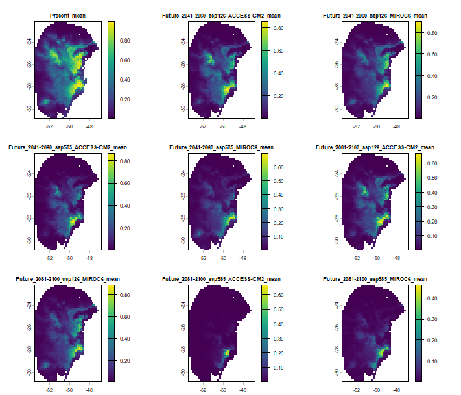

```r
# Import mean of each projected scenario
p_mean <- import_results(projection = p, consensus = "mean")

# Plot all scenarios
terra::plot(p_mean, cex.main = 0.8)
```

Alternatively, we can import results from specific scenarios. For example, let’s import the results only for the “2041-2060” time period under the SSP 126:

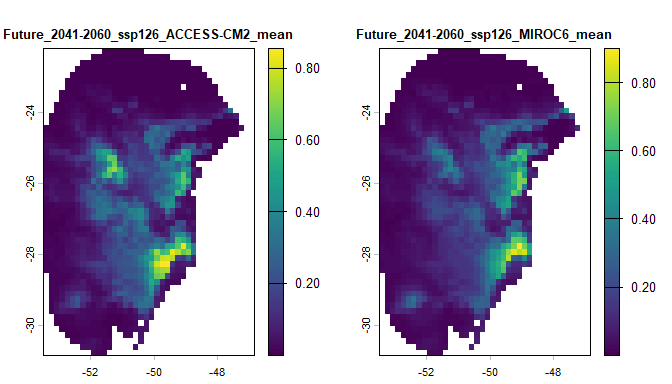

```r
# Importing
p_2060_ssp126 <- import_results(projection = p, consensus = "mean",
                                present = FALSE,  # Do not import present projections
                                future_period = "2041-2060",
                                future_pscen = "ssp126")

# Plot all scenarios
terra::plot(p_2060_ssp126, cex.main = 0.8)
```

With the `model_projections` object, we can compute changes in suitable areas (`projection_changes()`), explore variability patterns coming from replicates, parameterizations, and GCMs (`projection_variability()`), and perform analysis of extrapolation risks (`projection_mop()`). For more details, check Explore Variability and Uncertainty in Projections.

# Detecting changes in projections

When projecting a model to different scenarios (past or future), suitable areas can be classified into three categories relative to the current baseline: **gain**, **loss** and **stability**. The interpretation of these categories depends on the temporal direction of the projection.

**When projecting to future scenarios**:

- *Gain*: Areas currently unsuitable become suitable in the future.
- *Loss*: Areas currently suitable become unsuitable in the future.
- *Stability*: Areas remain the same in the future, suitable or unsuitable.

**When projecting to past scenarios**:

- *Gain*: Areas unsuitable in the past are suitable in the present.
- *Loss*: Areas suitable in the past are unsuitable in the present.
- *Stability*: Areas remain the same in the present, suitable or unsuitable.

These outcomes may vary across different General Circulation Models (GCMs) within each time scenario (e.g., various Shared Socioeconomic Pathways (SSPs) for the same period).

The `projection_changes()` function summarizes the number of GCMs predicting gain, loss, and stability for each time scenario.

By default, this function writes the summary results to disk (unless `write_results` is set to `FALSE`), but it does not save binary layers for individual GCMs. In the example below, we demonstrate how to configure the function to return the raster layers with changes and write the binary results to disk.

```r
# Run analysis to detect changes in suitable areas
changes <- projection_changes(model_projections = p,
                              output_dir = out_dir,
                              write_bin_models = TRUE,  # Write individual binary results
                              return_raster = TRUE)
```

## Setting colors for maps

Before plotting the results, we can use the `colors_for_changes()` function to assign custom colors to areas of gain, loss, and stability. By default, the function uses ‘teal green’ for gains, ‘orange-red’ for losses, ‘Oxford blue’ for areas that remain suitable, and ‘grey’ for areas that remain unsuitable. However, you can customize these colors as needed.

The intensity of each color is automatically adjusted based on the number of GCMs: highest (as defined by `max_alpha`) when all GCMs agree on a prediction, and decreases progressively (down to `min_alpha`) as fewer GCMs support that outcome.

```r
# Set colors for change maps
changes_col <- colors_for_changes(changes)
```

The function returns the same `changes_projections` object, but with color tables embedded in its `SpatRasters`. These colors are automatically applied when visualizing the data using `terra::plot()`.

## Types os results

The `projection_changes()` function returns four types of results: binary model prediction, results by GCM, results by change, and a general summary considering all GCMs:

- **Binary prediction for each GCM**: These are suitable/unsuitable maps for each individual GCM. By default, the omission error threshold used when selecting the best models is used (e.g., 10%). You can specify a different threshold using the `user_threshold` argument.

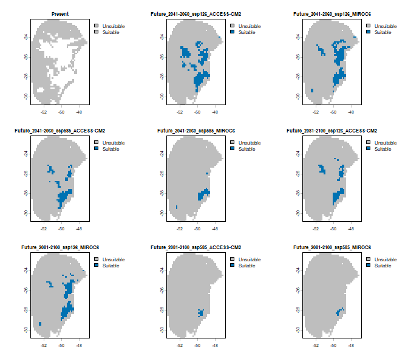

```r
terra::plot(changes_col$Binarized, cex.main = 0.8)
```

- **Results by GCM**: provides the changes identified in comparisons (gain, loss, stability) for each GCM individually.

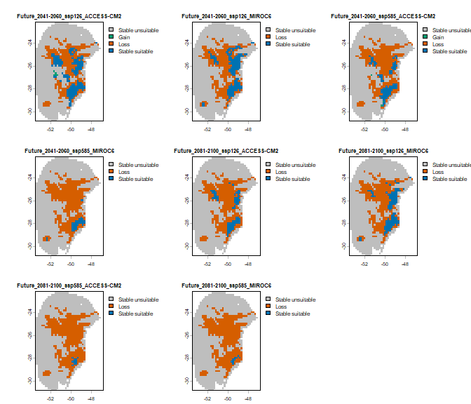

```r
terra::plot(changes_col$Results_by_gcm, cex.main = 0.8)
```

- **Results by change**: a list where each `SpatRaster` represents a specific type of change (e.g., gain, loss, stability) across all GCMs for a given scenario.

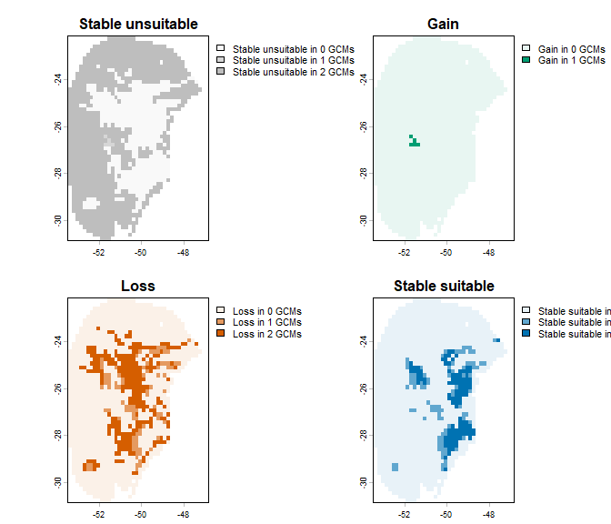

```r
# Results by change for the scenario of 2041-2060 (ssp126)
terra::plot(changes_col$Results_by_change$`Future_2041-2060_ssp126`)
```

- **Summary changes**: provides a general summary indicating how many GCMs project gain, loss, and stability for each scenario.

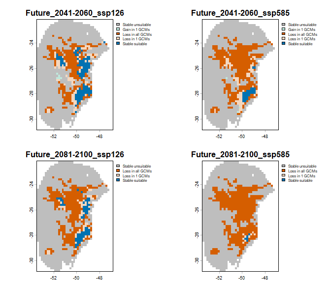

```r
terra::plot(changes_col$Summary_changes, plg = list(cex = 0.75))  # Decrease size of legend text
```

## Importing Results

When `return_raster = TRUE` is set, the resulting `SpatRaster` objects are returned within the `changes_projections` object. By default, however, `return_raster = FALSE` and the object only contains the directory path where the results were saved. In that case, the results can be imported using the `import_results()` function. You can specify the type of results to import, along with the target period and emission scenario.

A `changes_projections` object imported using `import_results()` can also be used as input to `colors_for_changes()` to customize the colors used for plotting.

For example, below we import only the general summary for the 2041–2060 period under the SSP5-8.5 scenario:

[figure not shown]

```r
# Import changes detected for 2041–2060 SSP5-8.5
general_changes <- import_results(projection = changes,
                                  future_period = "2041-2060",
                                  future_pscen = "ssp585",
                                  change_types = "summary")

# Set colors
general_changes <- colors_for_changes(general_changes)

# Plot
terra::plot(general_changes$Summary, main = names(general_changes$Summary),
            plg = list(cex = 0.75))  # Decrease size of legend text
```

## Saving results

The `changes_projections` object is a list that contains the resulting `SpatRaster` objects (if `return_raster = TRUE`) and the directory path where results were saved (if `write_results = TRUE`).

If results were not written to disk during the initial run, you can save `SpatRaster` objects afterward using the `writeRaster()` function. For example, to save the general summary raster:

```r
writeRaster(changes$Summary_changes,
            file.path(out_dir, "Summary_changes.tif"))
```

If the results were saved to disk, the `changes_projections` object is automatically stored in a folder named *Projection_changes* inside the specified `output_dir`. You can load it back into R using `readRDS()`:

```r
changes <- readRDS(file.path(out_dir, "Projection_changes/changes_projections.rds"))
```

After saving, this object can be used to import specific results with the `import_results()` function.

```r
# Reset plotting parameters
par(original_par)
```